# Master Thesis

[Philippine Louail](https://github.com/philouail)

2023-05-18

# 1. Packages

The followings packages were used within this project:

```
## [1] "patchwork, version used: 1.1.2"
## [1] "Seurat, version used: 4.3.0"
## [1] "tidyverse, version used: 2.0.0"
## [1] "scales, version used: 1.2.1"
## [1] "umap, version used: 0.2.10.0"
## [1] "data.table, version used: 1.14.8"
## [1] "scCustomize, version used: 1.1.1"
## [1] "celldex, version used: 1.8.0"
## [1] "SingleR, version used: 2.0.0"
## [1] "viridis, version used: 0.6.3"
## [1] "ggplot2, version used: 3.4.2"
## [1] "ggpubr, version used: 0.6.0"
## [1] "bibtex, version used: 0.5.1"
```

# 2. Dataset

Two datasets were selected for this project based on their respective metadata information available. Metadata information needed were: -Pathology status: Non-malignant or High-grade Serous ovarian cancer samples -Location: Sample has to be taken from the ovary only -Patient information on: Age, menopause status, FIGO stage of the cancer.

The datasets were open individually and a Seurat object was created for each. The same selection thresholds were applied to both.

## 2.1. Xu et al. 2022

The matrix and metadata were separated for each individuals of the dataset. A “for loop” was build to quickly create a Seurat object that combine the count matrix and metadata of each patients.

### 2.1.1 First for the Cancer/maligant samples:

```r
setwd("GSE184880_XU/Cancer")

listcsv <- dir(pattern = "*.csv")
listdata <- dir(pattern = "*_GSM55992*" )

for (k in 1:7){
  datacancer <- Read10X(listdata[k])
  meta<-  fread(listcsv[k])
  cell_names <- data.frame(cell_label = colnames(datacancer),
                           Sample_name = as.character(meta$Sample_name),
                           stringsAsFactors = FALSE,
                           row.names = colnames(datacancer))
  meta$Sample_name <- as.character(meta$Sample_name)
  meta_seurat <- left_join(x = cell_names,
                           y = meta,
                           by = "Sample_name")
  stopifnot(all.equal(meta_seurat$cell_label, cell_names$cell_label))

  rownames(meta_seurat) <- meta_seurat$cell_label

  mydata <- CreateSeuratObject(datacancer, min.cells = 10,
                               min.features = 500,
                               project = paste("XU_OC", k, sep="_"),
                               meta.data = meta_seurat)
  saveRDS(mydata, file= paste("XU_SeuratObj", k , ".rds" , sep=""))
}
```

There are 7 malignant individuals.

The Seurat objects were then grouped together:

```r
setwd("GSE184880_XU/Cancer")

XUSeuratlist <-list.files(pattern = ".rds") %>%
            map(readRDS)
XuSeurat<-Merge_Seurat_List(XUSeuratlist)
XuSeurat[["percent.mt"]] <- PercentageFeatureSet(XuSeurat, pattern = "^MT-")
```

A quality control was performed:

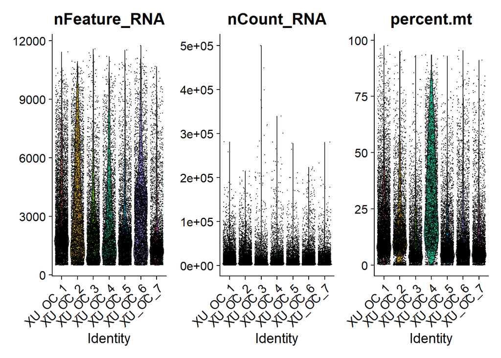

```r
VlnPlot(XuSeurat, features = c("nFeature_RNA", "nCount_RNA", "percent.mt"),
        ncol = 3)
```

```r
#subset QC
XuSeurat <- subset(XuSeurat, subset = nFeature_RNA < 6000 & percent.mt < 25)

saveRDS(XuSeurat,"Xu_SeuratObj_Cancer_SusbsetQC.rds")
```

### 2.1.2 A similar worlkflow was then performed for the non-malignant samples

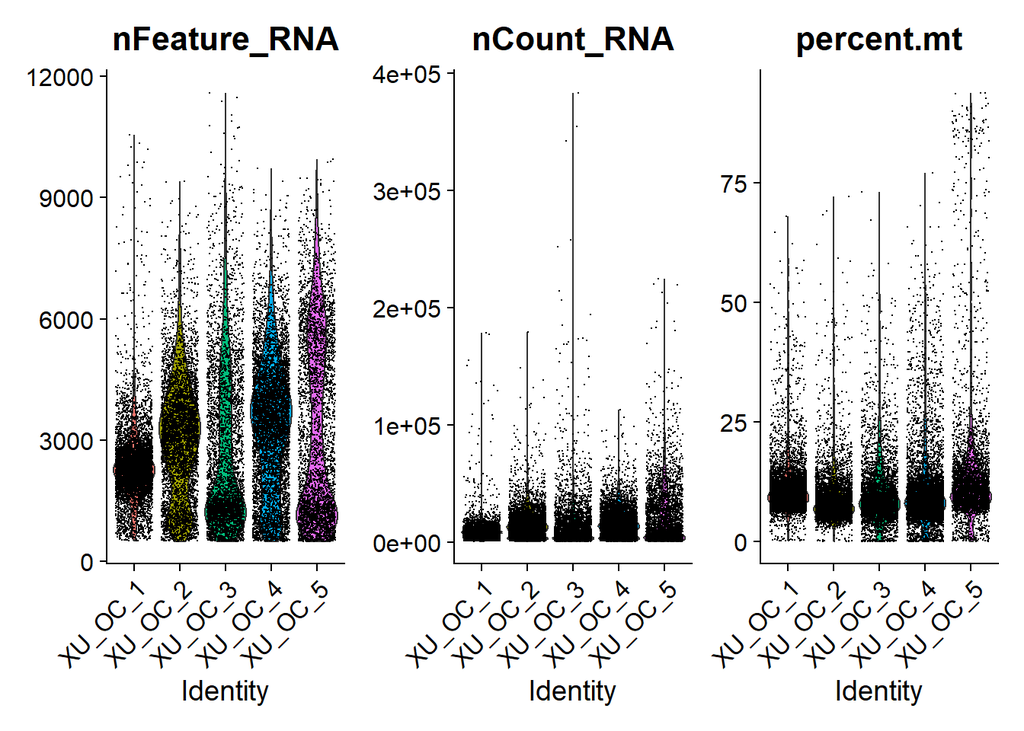

```r
setwd("GSE184880_XU/Norm")
#create a list
listcsv <- dir(pattern = "*.csv")
listdata <- dir(pattern = "*_GSM55992*")

#loop seurat object
for (k in 1:5){
  datacancer <- Read10X(listdata[k])
  meta<-  fread(listcsv[k])
  cell_names <- data.frame(cell_label = colnames(datacancer),
                           Sample_name = as.character(meta$Sample_name),
                           stringsAsFactors = FALSE,
                           row.names = colnames(datacancer))
  meta$Sample_name <- as.character(meta$Sample_name)
  meta_seurat <- left_join(x = cell_names,
                           y = meta,
                           by = "Sample_name")
  stopifnot(all.equal(meta_seurat$cell_label, cell_names$cell_label))

  rownames(meta_seurat) <- meta_seurat$cell_label

  mydata <- CreateSeuratObject(datacancer, min.cells = 10,
                               min.features = 500,
                               project = paste("XU_OC", k, sep="_"),
                               meta.data = meta_seurat)
  saveRDS(mydata, file= paste("XU_SeuratObj", k , ".rds" , sep=""))

}

#create a common Seurat file
XUSeuratlist <-list.files(pattern = ".rds") %>%
  map(readRDS)
XuSeurat<-Merge_Seurat_List(XUSeuratlist)

#QC
XuSeurat[["percent.mt"]] <- PercentageFeatureSet(XuSeurat, pattern = "^MT-")

VlnPlot(XuSeurat, features = c("nFeature_RNA", "nCount_RNA", "percent.mt"),
        ncol = 3)
```

```r
#subset QC
XuSeurat <- subset(XuSeurat, subset = nFeature_RNA > 200 &
                     nFeature_RNA < 6000 & percent.mt < 25)
```

```r
saveRDS(XuSeurat,"Xu_SeuratObj_Norm_SusbsetQC.rds")
```

There is 5 non-malignant individuals.

## 2.2 Olbretch et al. 2021

For this dataset, all the samples were pooled together. However, some did not match our selection criteria described above. It was therefore subsetted after the Seurat object was created.

```r
setwd("EGAS00001004987_OLBRECHT")

metaOB <- fread("2093-Olbrecht_metadata.csv")
countOB <- readRDS("2095-Olbrecht_counts_matrix.rds")

# we need to import the original metadata in order to identify the samples we want to keep
# the following code is from the the original publication
cell_names <- data.frame(cell_label = colnames(countOB),
                         sample_name = sub(".*_(.*)",
                                           "\\1",
                                           colnames(countOB)),
                         stringsAsFactors = FALSE,
                         row.names = colnames(countOB))
stopifnot(all(cell_names$sample_name %in% metaOB$sample_name))
meta_seurat <- left_join(x = cell_names,
                         y = as.data.frame(metaOB),
                         by = "sample_name")

# left_join preserves the order of cells:
stopifnot(all.equal(meta_seurat$cell_label, cell_names$cell_label))

#Seurat needs rownames to merge metadata and matrix: add cell labels as rownames
rownames(meta_seurat) <- meta_seurat$cell_label

#Create Seurat object
OLBRECHT <- CreateSeuratObject(countOB,
                        project          = "Olbrecht_OC",
                        min.cells        = 10,     # only genes > 10 cells
                        min.genes        = 500,    # only cells with > 200 genes
                        meta.data        = meta_seurat)
```

Before subsetting, the dataset has 7 individuals and 12 samples. The samples of interest matching our metadata criteria were: OB_5, OB_8 and OB_9.

```r
OLBRECHT_Seurat <- subset(OLBRECHT, ID == c("OB_5","OB_8","OB_9"))
```

This subsetted dataset had 2 individuals and 3 samples.

Quality control was then performed in a similar way as for the previous dataset

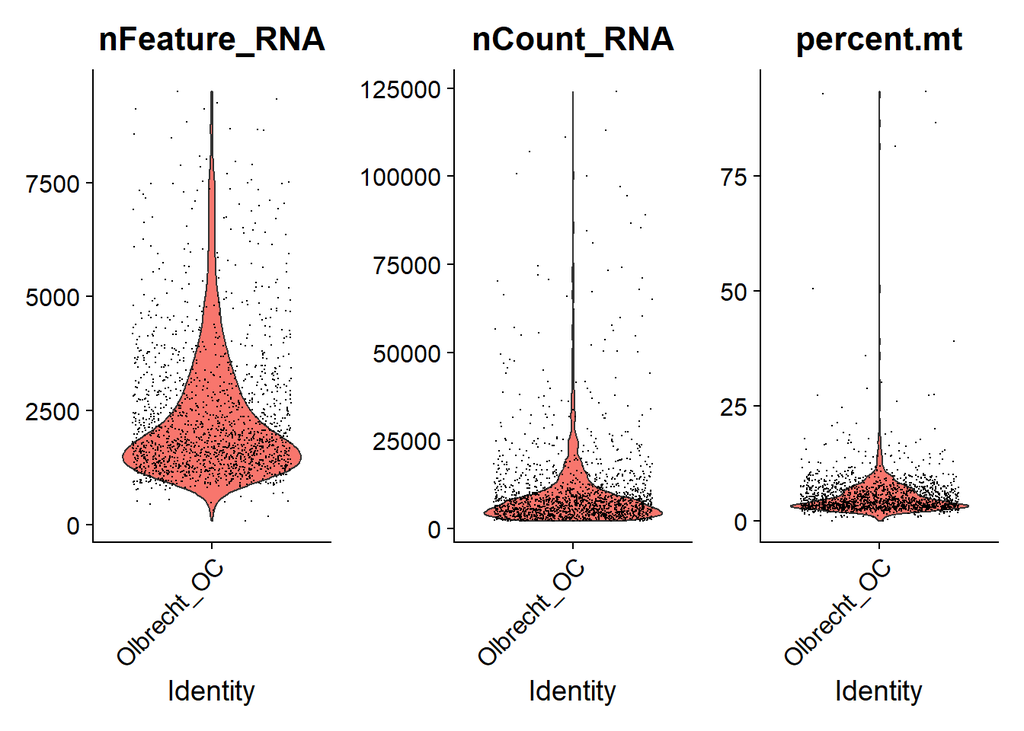

```r
#adding percent.mt column to object
OLBRECHT_Seurat[["percent.mt"]] <- PercentageFeatureSet(OLBRECHT_Seurat,
                                                        pattern = "^MT-")
# Visualize QC metrics as a violin plot
VlnPlot(OLBRECHT_Seurat,
        features = c("nFeature_RNA", "nCount_RNA", "percent.mt"), ncol = 3)
```

```r
#subset QC
OLBRECHT_Seurat <- subset(OLBRECHT_Seurat,
                          subset = nFeature_RNA > 200 &
                            nFeature_RNA < 6000 &
                            percent.mt < 25)
saveRDS(OLBRECHT_Seurat,"Olbrecht_SeuratObj_SusbsetQC.rds")
```

# 3. Integration

The three datasets were then integrated together: - Xu et al malignant samples - Xu et al normal samples - Olbrecht et al malignant + normal samples

First a list combining the datasets was created:

```r
XuC<- readRDS("Xu_SeuratObj_Cancer_SusbsetQC.rds")
XuN<- readRDS("Xu_SeuratObj_Norm_SusbsetQC.rds")
OB<- readRDS("Olbrecht_SeuratObj_SusbsetQC.rds")
Seuratlist <- list(OB, XuC, XuN)
saveRDS(Seuratlist, "Integrated_SeuratObj.rds")
```

The “variable features” (genes) were identified and normalized.

```r
Seuratlist <- readRDS("Integrated_SeuratObj.rds")
Seuratlist <- lapply(X = Seuratlist, FUN = function(x) {
  x <- NormalizeData(x)
  x <- FindVariableFeatures(x, selection.method = "vst", nfeatures = 2000)
})
```

Then features that were repeatedly variable across datasets were selected as a basis for the integration and a PCA was ran using these features.

```r
features <- SelectIntegrationFeatures(object.list =Seuratlist)
Seuratlist <- lapply(X = Seuratlist, FUN = function(x) {
  x <- ScaleData(x, features = features, verbose = FALSE)
  x <- RunPCA(x, features = features, verbose = FALSE)
})

anchors <- FindIntegrationAnchors(object.list = Seuratlist,
                                         anchor.features = features,
                                         reduction = "rpca") #reciprocal PCA
```

Another assay was created within the Seurat object called ‘integrated’ and was set as default such that downstream analysis was performed on it. However, the original unmodified data was still available for downstream analysis under the ‘RNA’ assay.

```r
Seurat.combined <- IntegrateData(anchorset = anchors)
DefaultAssay(Seurat.combined) <- "integrated"
```

The standard workflow for visualization and clustering was run on our integrated dataset.

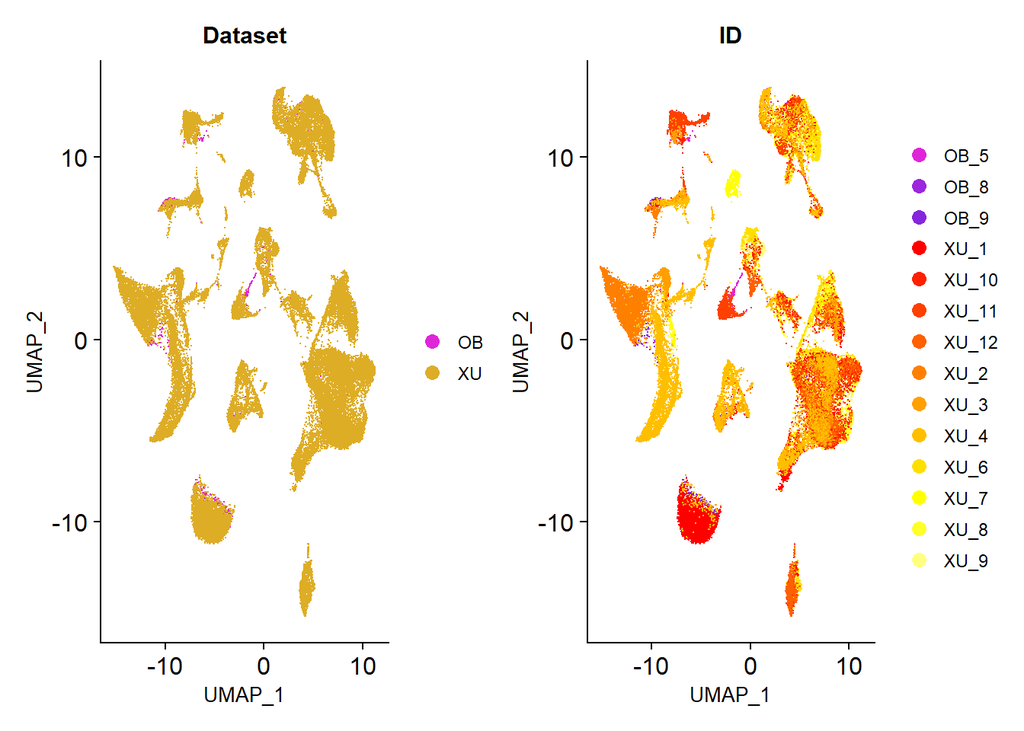

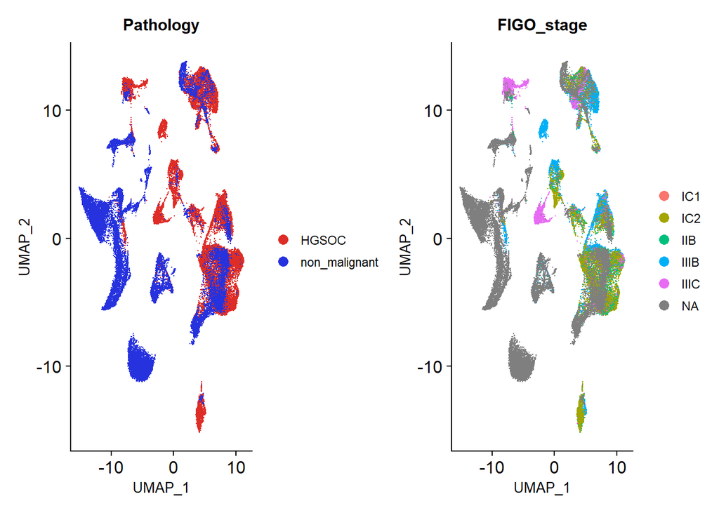

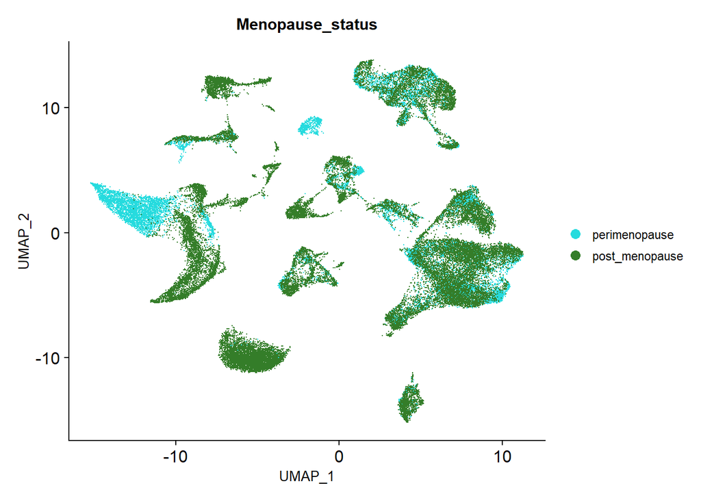

```r
Seurat.combined <- ScaleData(Seurat.combined, verbose = FALSE)
Seurat.combined <- RunPCA(Seurat.combined, npcs = 30, verbose = FALSE)
Seurat.combined <- RunUMAP(Seurat.combined, reduction = "pca", dims = 1:30)
Seurat.combined <- FindNeighbors(Seurat.combined, reduction = "pca", dims =1:30)
Seurat.combined <- FindClusters(Seurat.combined, resolution = 0.5)

saveRDS(Seurat.combined, "Seurat_combined_OB_XuC_XuN.rds")


p1 <- DimPlot(Seurat.combined, reduction = "umap", group.by ="Pathology", cols = c('#de2d26', '#2632de'), label.size = 2)+
  theme(text = element_text(size = 10))
p2 <- DimPlot(Seurat.combined, reduction = "umap", group.by ="Dataset", cols = c('#de26d8','#dead26' ), label.size = 2)+
  theme(text = element_text(size = 10))
p3 <- DimPlot(Seurat.combined, reduction = "umap", group.by ="Menopause_status", cols = c("#26dbde" ,"#347d29"), label.size = 2)+
  theme(text = element_text(size = 10))
p4 <- DimPlot(Seurat.combined, reduction = "umap", group.by ="FIGO_stage", na.value= "#e6e3e3"  ,label.size = 2)+
  theme(text = element_text(size = 10))
p6 <- DimPlot(Seurat.combined, reduction = "umap", group.by ="ID", cols = c("#de26d8","#9b26de", "#8526de", heat.colors(12)), label.size = 2)+
  theme(text = element_text(size = 10))
```

The integrated dataset was comprised of 14 patients,26439 genes and 50216 cells in total.

# 4. Cluster identification

## 4.1 Unibased

Using the SingleR package an unbiased pheatmap was created displaying the possible identity of our clusters based on the Human primary cell atlas data available. This package used well-known marker from this reference dataset to assign identity to the clusters of our datasets

```r
Seurat.combined<- readRDS("Seurat_combined_OB_XuC_XuN.rds")

ref.data <- celldex::HumanPrimaryCellAtlasData(ensembl=FALSE)
prediction <- SingleR(test=Seurat.combined@assays$RNA@counts , ref= ref.data ,
                      labels= ref.data$label.main)

table(prediction$labels)

unbiased.annotation <- table(cluster= Seurat.combined$seurat_clusters,
                             label=prediction$labels)
```

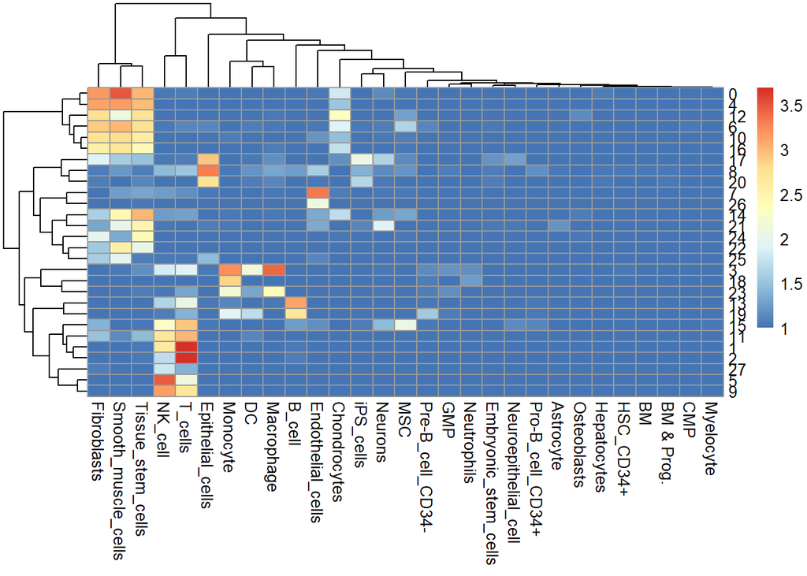

```r
pheatmap::pheatmap(log10(unbiased.annotation+10), width = 6, height = 6)
```

The same protocol was run but this time using a Immune cell database

```r
ref.data <- celldex::DatabaseImmuneCellExpressionData(ensembl=FALSE)
ref.data
prediction.immune <- SingleR(test=Seurat.combined@assays$RNA@counts , ref= ref.data , labels= ref.data$label.main)
table(prediction.immune$labels)
immune.annotation <- table(cluster= Seurat.combined$seurat_clusters, label=prediction.immune$labels)
```

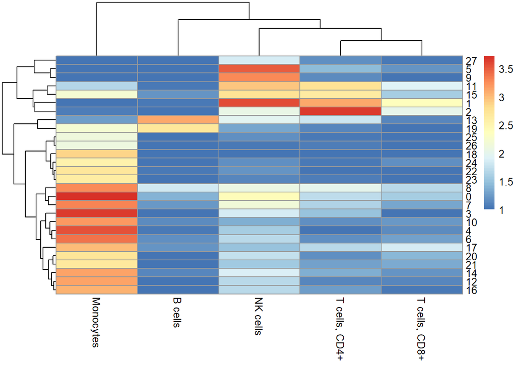

```r
pheatmap::pheatmap(log10(immune.annotation+10), width = 6, height = 6)
```

## 4.2 Biased identification

For biased cluster identification, vectors of well-known cell-type specific markers were create.

```r
#Stroma
Tumor_cell_marker <- c("EPCAM", "KRT7", "KRT18", "PAX8", "CD24")
Endothelial_markers <- c("CLDN5", "PECAM1", "VWF", "CD34")
Fibroblasts_markers <- c("COL1A1", "COL1A2","DCN", "COL3A1","FBN1")
Epithelia <- c("CDH1","CLDN1","KRT6A","MUC1","KRT8")
granulosa <- c("AMH", "HSD17B1",'CYP19A1' )
mcaf <- c("THY1", "FAP", "PDGFRB")

#Tcell refinment
Tcell <- c("IL7R", "CCR7", "CD3E", "CD4", "CD8A","CTLA4","FOXP3","THEMIS")

#Bcell&plasmacells
Bcell <- c( "SDC1", "CD79A","CD38", "CD79B", "CD19", "IGHG3", "IGKC",
            "JCHAIN", "VPREB3","IGLL5","CPNE5","MS4A1","JSRP1","RASSF6" )
#monocyte
Myeloid_cells<- c('CD68' ,'LYZ' ,'AIF1')
macrophages <- c("CD14" , "CD163")

NK<- c("KIR2DL4", "NCR1", 'KLRC1', 'KLRC3', "GNLY", "NKG7" )
```

And dotplots were ran and generated dot plots for each. Here are a few examples for mCAFs:

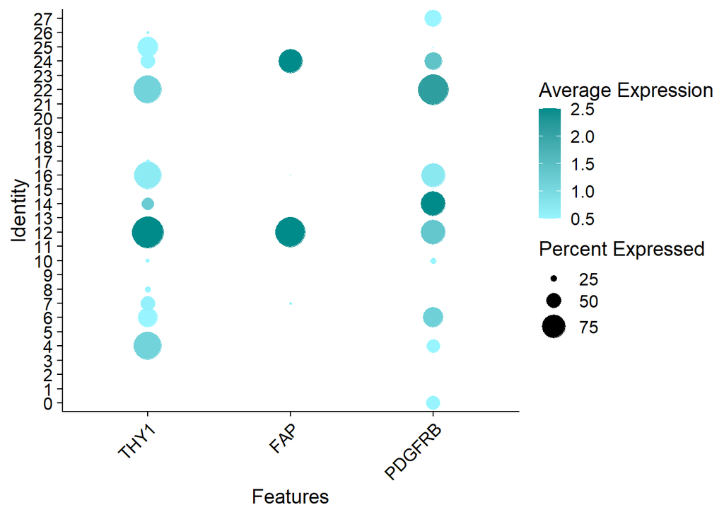

```r
DotPlot(Seurat.combined,  features= mcaf,
        assay = "RNA",
        cols =  c("cadetblue1", "darkcyan"),
        dot.min = 0.10,col.min = 0.5,dot.scale = 10)+ RotatedAxis()
```

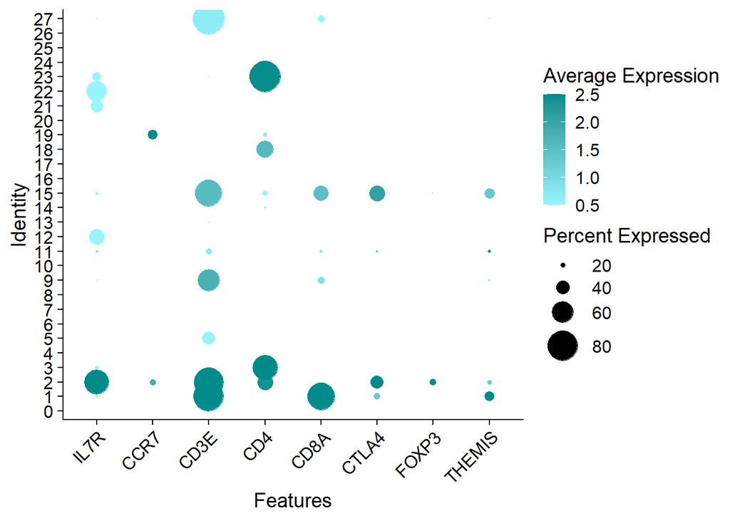

```r
DotPlot(Seurat.combined,  features= Tcell,
        assay = "RNA",
        cols =  c("cadetblue1", "darkcyan"),
        dot.min = 0.10,col.min = 0.5,dot.scale = 10)+ RotatedAxis()
```

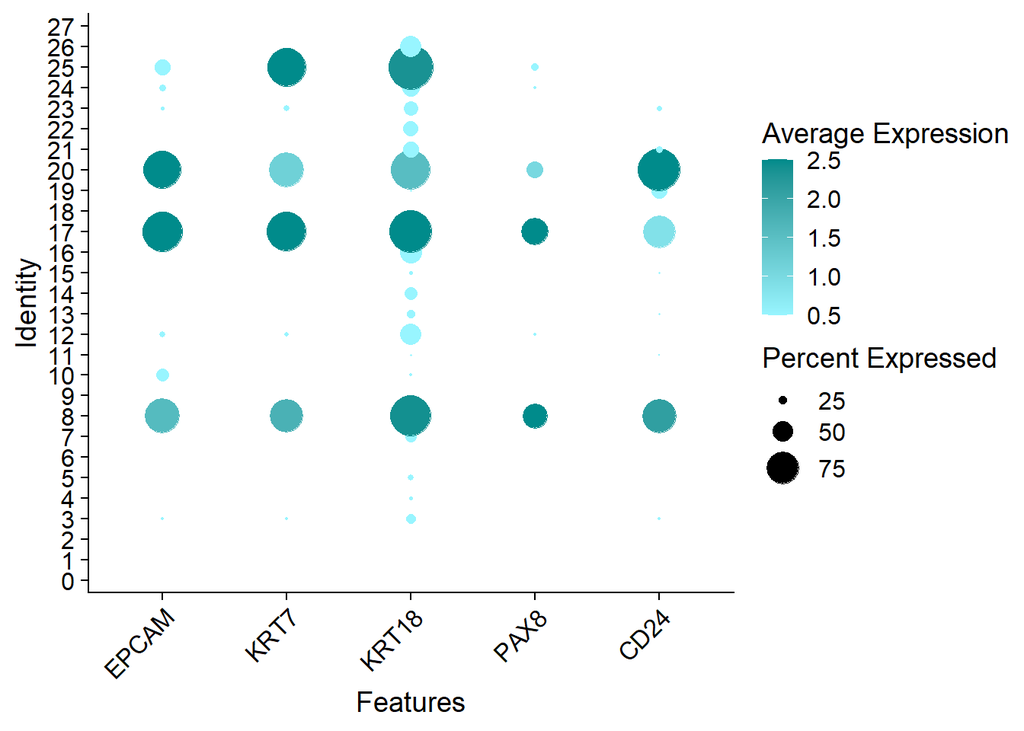

```r
DotPlot(Seurat.combined,  features= Tumor_cell_marker,
        assay = "RNA",
        cols =  c("cadetblue1", "darkcyan"),
        dot.min = 0.10,col.min = 0.5,dot.scale = 10)+ RotatedAxis()
```

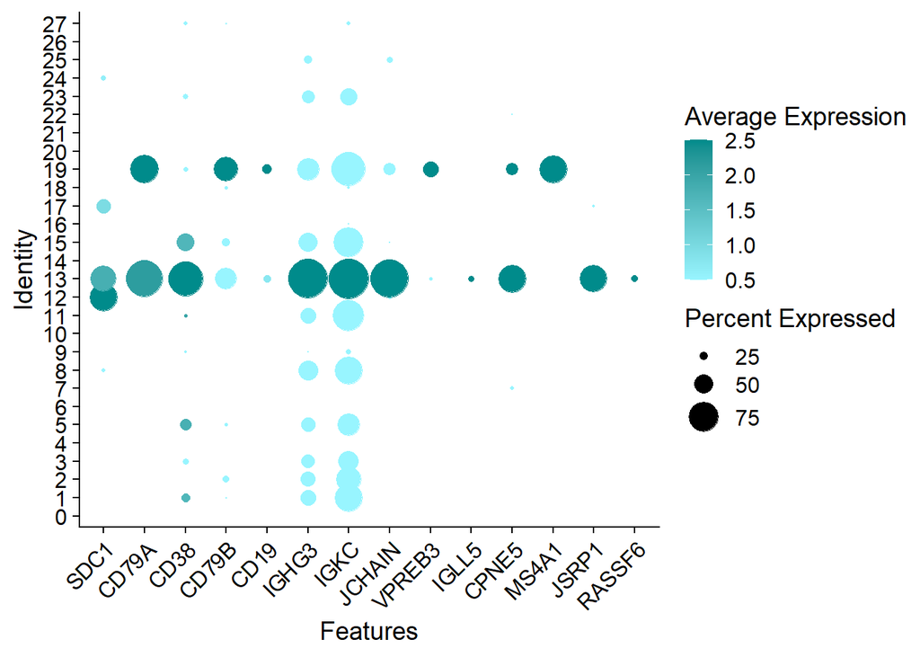

```r
DotPlot(Seurat.combined,  features= Bcell,
        assay = "RNA",
        cols =  c("cadetblue1", "darkcyan"),
        dot.min = 0.10,col.min = 0.5,dot.scale = 10)+ RotatedAxis()
```

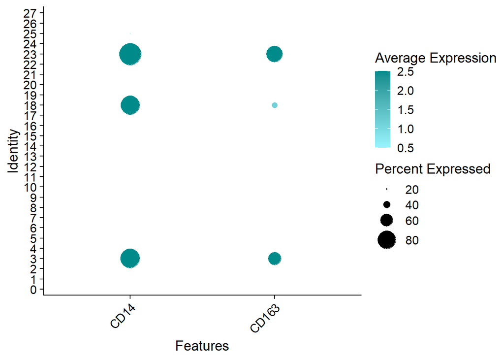

```r
DotPlot(Seurat.combined,  features= macrophages,
        assay = "RNA",
        cols =  c("cadetblue1", "darkcyan"),
        dot.min = 0.10,col.min = 0.5,dot.scale = 10)+ RotatedAxis()
```

Both the combined the biased and unbiased approaches were combined to annotate the clusters and build this Umap:

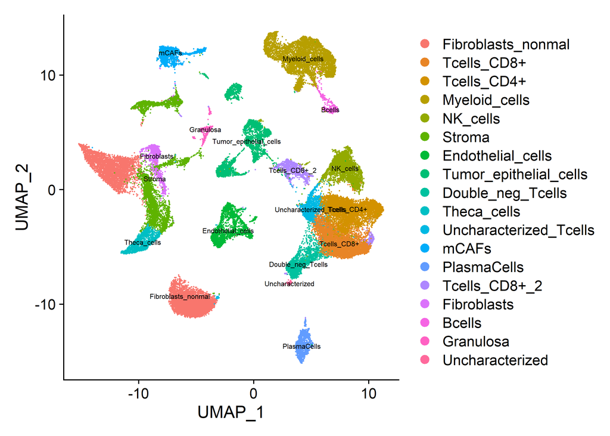

The Stroma ovarian being quite complex, the clusters for these cell types where harder to identify confidently. Moreover this project focused more toward immunophenotyping of HGSOC. Immune cell clusters identification was therefore the priority, as well as mCAFs as they seem to have a role in how patients respond to immunotherapy.

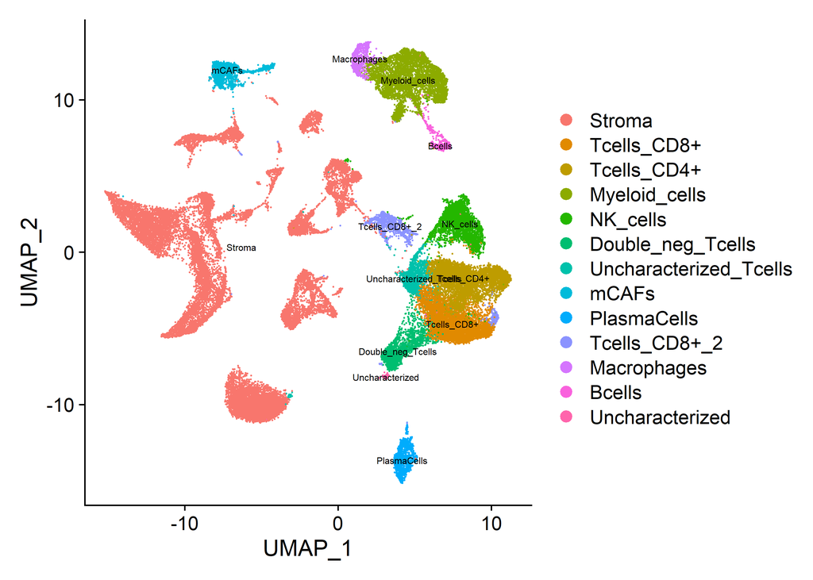

## 4.3 Panel building

A robust 9-plex IF antibody panel was built by combining information from multiple sources. Firstly, the internal antibody HPA database was utilized to identify potential targets. Additionally, existing literature on immunophenotyping and immunotherapy in cancer, specifically focusing on HGSOC, was reviewed. Finally, the scRNA-sequencing results were analyzed to further refine the panel. Through this process, a comprehensive panel for studying the spatial cell type/state-specific localization within ovarian tissue, specifically targeting the immune phenotype, was generated.

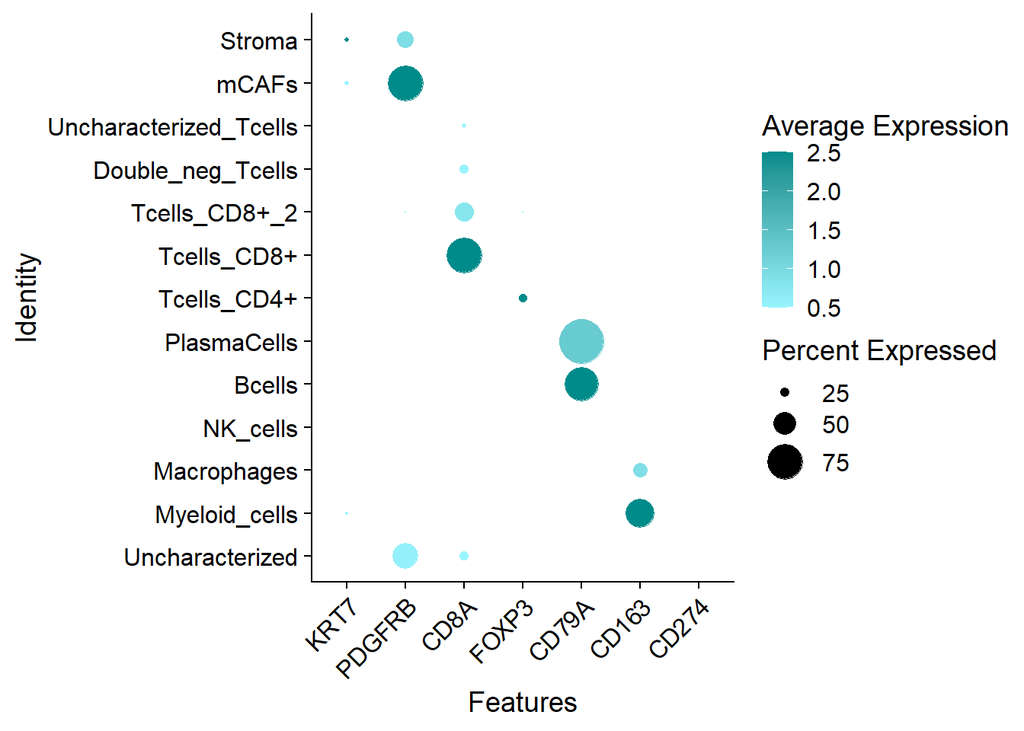

## 4.4 Marker of interest in our datasets

As I was building the panel I also searched for transcriptomic markers of interest that the scRNAseq re-analysis highlighted. These marker were meant to be used as “test-marker” in our 9-plex panel.

### 4.4.1 List creation

A “light” Seurat object was created based on internal HPA antibody list availability:

```r
Seurat.combined<- readRDS("Seurat_combined_OB_XuC_XuN.rds")

gene <- fread("export_2023-02-14 10-19-20.xls")

Antibodies <- gene %>% mutate_at(2, ~replace_na(.,0))%>%
  filter(!Multi.targeting == "1" )%>%
  filter (Reliability.Score=="4: High"
          | Reliability.Score== "3: Medium"
          | Reliability.Score== "2: Low"
          | Reliability.Score== "1: Very low")

genestokeep <- unique(Antibodies$Gene)

#Antibodies <- Antibodies1 %>% distinct(Gene, .keep_all=TRUE)

light.seurat <- subset(Seurat.combined, features = genestokeep)
saveRDS(light.seurat, "light.seurat.rds")
```

Within this list of validated HPA genes, a list of markers that were significantly different (Wilson cox statistical test) between different immune clusters was generated.

```r
clusters_of_interest <- c( "Tcells_CD8+", "Tcells_CD4+", "Myeloid_cells",
                           "Macrophages", "Bcells", "mCAFs" , "PlasmaCells" )
MasterList <- data.frame()
for (g in clusters_of_interest) {
  print(g)
  Markers<- FindMarkers(light.seurat,
                         ident.1 = g,
                         only.pos = TRUE, min.pct=0.80,
                         logfc.threshold = 0.25, test.use ="wilcox")
  Markers$Cell_type = g
  if (unique(Markers$Cell_type) == 1) {
    MasterList<- Markers
  } else {
    MasterList <- bind_rows(MasterList, Markers)
  }
}

MasterList$Gene <- rownames(MasterList)

MasterList <- merge( MasterList[,-c(2,3,4, 5)],Antibodies %>% distinct(Gene, .keep_all=TRUE), by = "Gene")

write.csv(MasterList, "MasterList_HGSOC.csv" , row.names = FALSE)
```

### 4.4.2 Selected for this project

In order to get a proof of concept for our new panel, the marker chosen from the list for this project were relatively well supported by the literature in the context of immunotherapy and/or HGSOC.

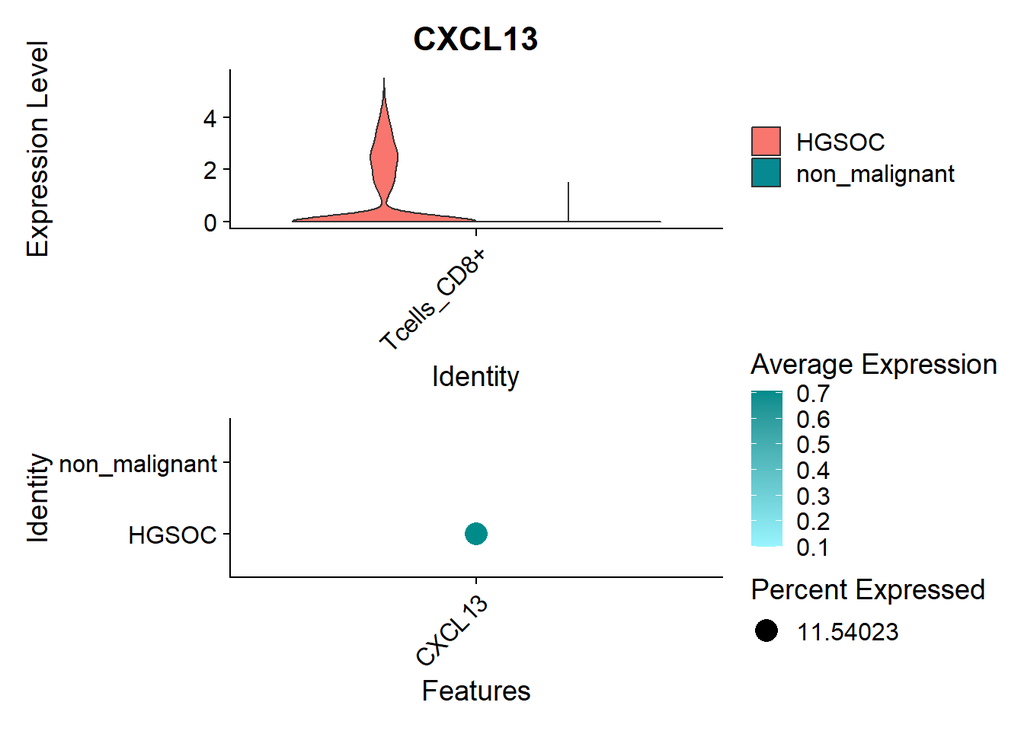

```r
Seurat.combined<- readRDS("Seurat_combined_OB_XuC_XuN.rds")

VlnPlot(Seurat.combined, assay = "RNA" , features = "CXCL13",
        split.by = "Pathology", idents= "Tcells_CD8+",
        pt.size = 0) + DotPlot(Seurat.combined,  features= "CXCL13",
        assay = "RNA", group.by = "Pathology",
        cols =  c("cadetblue1", "darkcyan"),
        dot.min = 0.10,col.min = 0.1,dot.scale = 10)+ RotatedAxis()
```

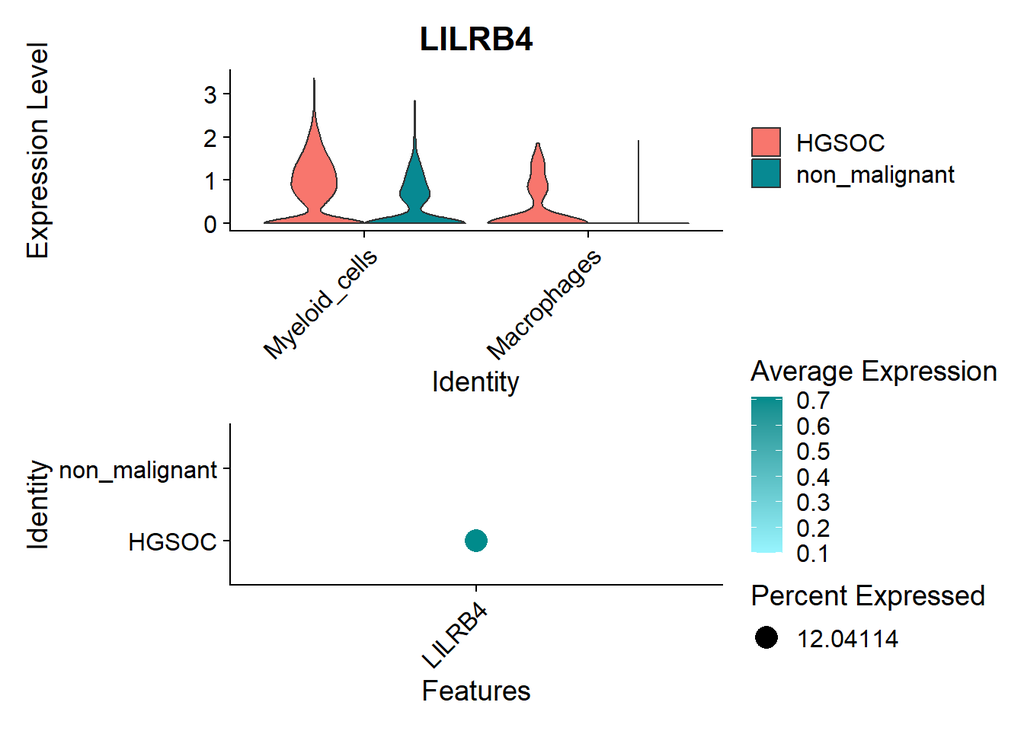

```r
VlnPlot(Seurat.combined, assay = "RNA" , features = "LILRB4",
        split.by = "Pathology", idents= c("Myeloid_cells", "Macrophages"),
        pt.size = 0 ) + DotPlot(Seurat.combined,  features= "LILRB4",
        assay = "RNA", group.by = "Pathology",
        cols =  c("cadetblue1", "darkcyan"),
        dot.min = 0.10,col.min = 0.1,dot.scale = 10)+ RotatedAxis()
```

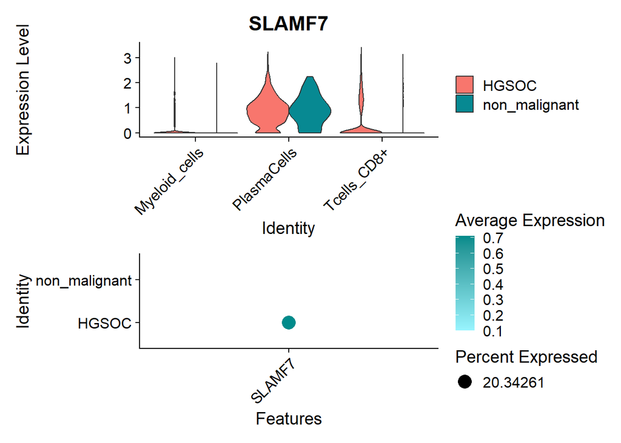

```r
VlnPlot(Seurat.combined, assay = "RNA" , features = "SLAMF7",
        split.by = "Pathology", idents= c("Myeloid_cells", "PlasmaCells",  "Tcells_CD8+"),
        pt.size = 0) + DotPlot(Seurat.combined,  features= "SLAMF7",
        assay = "RNA", group.by = "Pathology",
        cols =  c("cadetblue1", "darkcyan"),
        dot.min = 0.10,col.min = 0.1,dot.scale = 10)+ RotatedAxis()
```

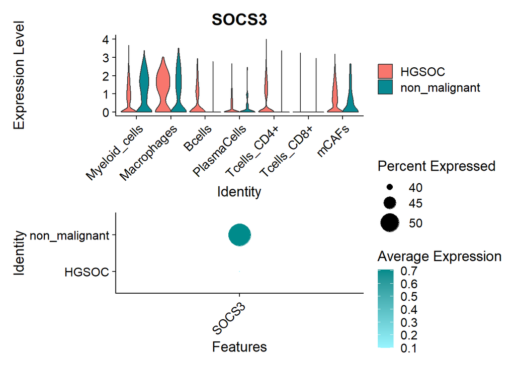

```r
VlnPlot(Seurat.combined, assay = "RNA" , features = "SOCS3",
        split.by = "Pathology", idents= c("Tcells_CD8+", "Tcells_CD4+", "Myeloid_cells",
                           "Macrophages", "Bcells", "mCAFs" , "PlasmaCells" ),
        pt.size = 0 ) + DotPlot(Seurat.combined,  features= "SOCS3",
        assay = "RNA", group.by = "Pathology",
        cols =  c("cadetblue1", "darkcyan"),
        dot.min = 0.10,col.min = 0.1,dot.scale = 10)+ RotatedAxis()
```

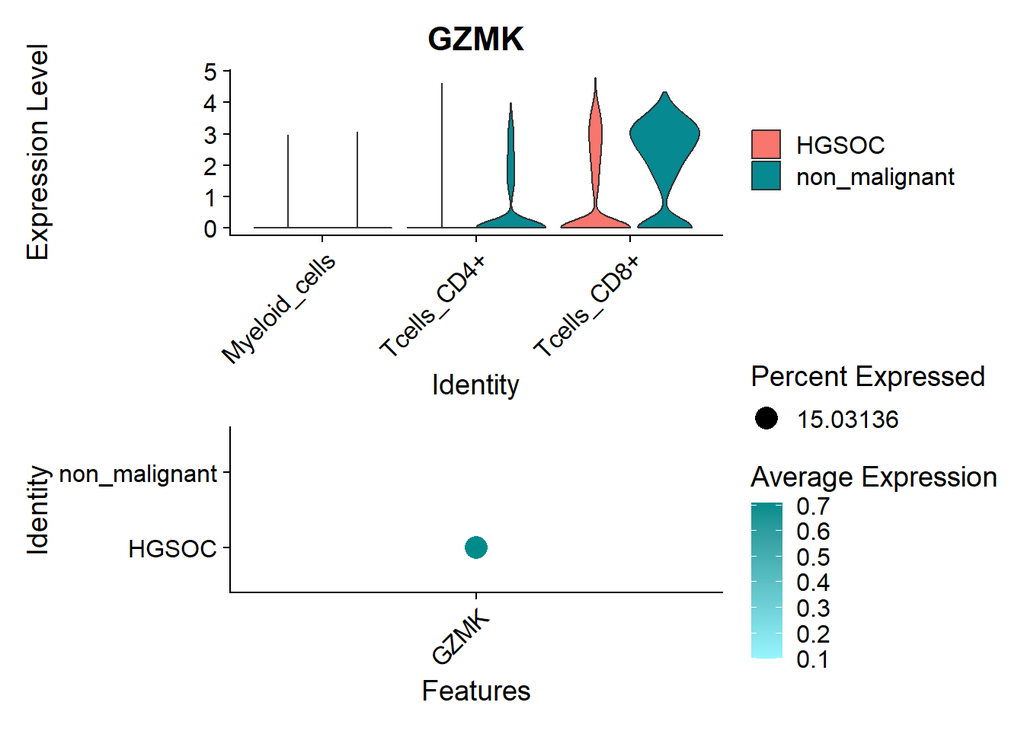

```r
VlnPlot(Seurat.combined, assay = "RNA" , features = "GZMK",
        split.by = "Pathology", idents= c("Tcells_CD8+", "Tcells_CD4+", "Myeloid_cells"),
        pt.size = 0 ) + DotPlot(Seurat.combined,  features= "GZMK",
        assay = "RNA", group.by = "Pathology",
        cols =  c("cadetblue1", "darkcyan"),
        dot.min = 0.10,col.min = 0.1,dot.scale = 10)+ RotatedAxis()
```

# References

Aboyoun, Patrick, Hervé Pagès, and Michael Lawrence. 2022. *GenomicRanges: Representation and Manipulation of Genomic Intervals*. https://bioconductor.org/packages/GenomicRanges.

Ahlmann-Eltze, Constantin, Peter Hickey, and Hervé Pagès. 2022. *MatrixGenerics: S4 Generic Summary Statistic Functions That Operate on Matrix-Like Objects*. https://bioconductor.org/packages/MatrixGenerics.

Aran, Dvir. 2022. *SingleR: Reference-Based Single-Cell RNA-Seq Annotation*. https://github.com/LTLA/SingleR.

Aran, Dvir, Agnieszka P. Looney, Leqian Liu, Esther Wu, Valerie Fong, Austin Hsu, Suzanna Chak, et al. 2019b. “Reference-Based Analysis of Lung Single-Cell Sequencing Reveals a Transitional Profibrotic Macrophage.” *Nat. Immunol.* 20: 163–72. https://doi.org/10.1038/s41590-018-0276-y.

———, et al. 2019a. “Reference-Based Analysis of Lung Single-Cell Sequencing Reveals a Transitional Profibrotic Macrophage.” *Nat. Immunol.* 20: 163–72. https://doi.org/10.1038/s41590-018-0276-y.

Aran, Dvir, Aaron Lun, Daniel Bunis, Jared Andrews, and Friederike Dündar. 2022. *Celldex: Reference Index for Cell Types*. https://github.com/LTLA/celldex.

Arora, Sonali, Martin Morgan, Marc Carlson, and Hervé Pagès. 2023. *GenomeInfoDb: Utilities for Manipulating Chromosome Names, Including Modifying Them to Follow a Particular Naming Style*. https://bioconductor.org/packages/GenomeInfoDb.

Bengtsson, Henrik. 2022. *matrixStats: Functions That Apply to Rows and Columns of Matrices (and to Vectors)*. https://github.com/HenrikBengtsson/matrixStats.

Butler, Andrew, Paul Hoffman, Peter Smibert, Efthymia Papalexi, and Rahul Satija. 2018. “Integrating Single-Cell Transcriptomic Data Across Different Conditions, Technologies, and Species.” *Nature Biotechnology* 36: 411–20. https://doi.org/10.1038/nbt.4096.

Dowle, Matt, and Arun Srinivasan. 2023. *Data.table: Extension of ‘Data.frame‘*. https://CRAN.R-project.org/package=data.table.

Francois, Romain, and Diego Hernangómez. 2023. *Bibtex: Bibtex Parser*. https://CRAN.R-project.org/package=bibtex.

Garnier, Simon. 2023a. *Viridis: Colorblind-Friendly Color Maps for r*. https://CRAN.R-project.org/package=viridis.

———. 2023b. *viridisLite: Colorblind-Friendly Color Maps (Lite Version)*. https://CRAN.R-project.org/package=viridisLite.

Garnier, Simon, Ross, Noam, Rudis, Robert, Camargo, et al. 2023a. *viridis(Lite) - Colorblind-Friendly Color Maps for r*. https://doi.org/10.5281/zenodo.4679424.

———, et al. 2023b. *viridis(Lite) - Colorblind-Friendly Color Maps for r*. https://doi.org/10.5281/zenodo.4678327.

Gentleman, R., V. Carey, M. Morgan, and S. Falcon. 2022. *Biobase: Base Functions for Bioconductor*. https://bioconductor.org/packages/Biobase.

Grolemund, Garrett, and Hadley Wickham. 2011. “Dates and Times Made Easy with lubridate.” *Journal of Statistical Software* 40 (3): 1–25. https://www.jstatsoft.org/v40/i03/.

Hao, Yuhan, Stephanie Hao, Erica Andersen-Nissen, William M. Mauck III, Shiwei Zheng, Andrew Butler, Maddie J. Lee, et al. 2021. “Integrated Analysis of Multimodal Single-Cell Data.” *Cell*. https://doi.org/10.1016/j.cell.2021.04.048.

Hoffman, Paul. 2022. *Seurat: Tools for Single Cell Genomics*. https://CRAN.R-project.org/package=Seurat.

Huber, W., V. J. Carey, R. Gentleman, S. Anders, M. Carlson, B. S. Carvalho, H. C. Bravo, et al. 2015a. “Orchestrating High-Throughput Genomic Analysis with Bioconductor.” *Nature Methods* 12 (2): 115–21. http://www.nature.com/nmeth/journal/v12/n2/full/nmeth.3252.html.

Huber, W., Carey, V. J., Gentleman, R., Anders, et al. 2015b. “Orchestrating High-Throughput Genomic Analysis with Bioconductor.” *Nature Methods* 12 (2): 115–21. http://www.nature.com/nmeth/journal/v12/n2/full/nmeth.3252.html.

Kassambara, Alboukadel. 2023. *Ggpubr: Ggplot2 Based Publication Ready Plots*. https://rpkgs.datanovia.com/ggpubr/.

Konopka, Tomasz. 2023. *Umap: Uniform Manifold Approximation and Projection*. https://github.com/tkonopka/umap.

Lawrence, Michael, Wolfgang Huber, Hervé Pagès, Patrick Aboyoun, Marc Carlson, Robert Gentleman, Martin Morgan, and Vincent Carey. 2013a. “Software for Computing and Annotating Genomic Ranges.” *PLoS Computational Biology* 9. https://doi.org/10.1371/journal.pcbi.1003118.

———. 2013b. “Software for Computing and Annotating Genomic Ranges.” *PLoS Computational Biology* 9. https://doi.org/10.1371/journal.pcbi.1003118.

Marsh, Samuel. 2023. *scCustomize: Custom Visualizations & Functions for Streamlined Analyses of Single Cell Sequencing*. https://CRAN.R-project.org/package=scCustomize.

Morgan, Martin, Valerie Obenchain, Jim Hester, and Hervé Pagès. 2022. *SummarizedExperiment: SummarizedExperiment Container*. https://bioconductor.org/packages/SummarizedExperiment.

Müller, Kirill, and Hadley Wickham. 2023. *Tibble: Simple Data Frames*. https://CRAN.R-project.org/package=tibble.

Pagès, Hervé, Patrick Aboyoun, and Michael Lawrence. 2022. *IRanges: Foundation of Integer Range Manipulation in Bioconductor*. https://bioconductor.org/packages/IRanges.

Pagès, Hervé, Michael Lawrence, and Patrick Aboyoun. 2023. *S4Vectors: Foundation of Vector-Like and List-Like Containers in Bioconductor*. https://bioconductor.org/packages/S4Vectors.

Pedersen, Thomas Lin. 2022. *Patchwork: The Composer of Plots*. https://CRAN.R-project.org/package=patchwork.

R Core Team. 2022. *R: A Language and Environment for Statistical Computing*. Vienna, Austria: R Foundation for Statistical Computing. https://www.R-project.org/.

Satija, Rahul, Andrew Butler, Paul Hoffman, and Tim Stuart. 2022. *SeuratObject: Data Structures for Single Cell Data*. https://CRAN.R-project.org/package=SeuratObject.

Satija, Rahul, Jeffrey A Farrell, David Gennert, Alexander F Schier, and Aviv Regev. 2015. “Spatial Reconstruction of Single-Cell Gene Expression Data.” *Nature Biotechnology* 33: 495–502. https://doi.org/10.1038/nbt.3192.

Spinu, Vitalie, Garrett Grolemund, and Hadley Wickham. 2023. *Lubridate: Make Dealing with Dates a Little Easier*. https://CRAN.R-project.org/package=lubridate.

Stuart, Tim, Andrew Butler, Paul Hoffman, Christoph Hafemeister, Efthymia Papalexi, William M Mauck III, Yuhan Hao, Marlon Stoeckius, Peter Smibert, and Rahul Satija. 2019. “Comprehensive Integration of Single-Cell Data.” *Cell* 177: 1888–1902. https://doi.org/10.1016/j.cell.2019.05.031.

Team, The Bioconductor Dev. 2022. *BiocGenerics: S4 Generic Functions Used in Bioconductor*. https://bioconductor.org/packages/BiocGenerics.

Wickham, Hadley. 2016. *Ggplot2: Elegant Graphics for Data Analysis*. Springer-Verlag New York. https://ggplot2.tidyverse.org.

———. 2022. *Stringr: Simple, Consistent Wrappers for Common String Operations*. https://CRAN.R-project.org/package=stringr.

———. 2023a. *Forcats: Tools for Working with Categorical Variables (Factors)*. https://CRAN.R-project.org/package=forcats.

———. 2023b. *Tidyverse: Easily Install and Load the Tidyverse*. https://CRAN.R-project.org/package=tidyverse.

Wickham, Hadley, Mara Averick, Jennifer Bryan, Winston Chang, Lucy D’Agostino McGowan, Romain François, Garrett Grolemund, et al. 2019. “Welcome to the tidyverse.” *Journal of Open Source Software* 4 (43): 1686. https://doi.org/10.21105/joss.01686.

Wickham, Hadley, Winston Chang, Lionel Henry, Thomas Lin Pedersen, Kohske Takahashi, Claus Wilke, Kara Woo, Hiroaki Yutani, and Dewey Dunnington. 2023. *Ggplot2: Create Elegant Data Visualisations Using the Grammar of Graphics*. https://CRAN.R-project.org/package=ggplot2.

Wickham, Hadley, Romain François, Lionel Henry, Kirill Müller, and Davis Vaughan. 2023. *Dplyr: A Grammar of Data Manipulation*. https://CRAN.R-project.org/package=dplyr.

Wickham, Hadley, and Lionel Henry. 2023. *Purrr: Functional Programming Tools*. https://CRAN.R-project.org/package=purrr.

Wickham, Hadley, Jim Hester, and Jennifer Bryan. 2023. *Readr: Read Rectangular Text Data*. https://CRAN.R-project.org/package=readr.

Wickham, Hadley, and Dana Seidel. 2022. *Scales: Scale Functions for Visualization*. https://CRAN.R-project.org/package=scales.

Wickham, Hadley, Davis Vaughan, and Maximilian Girlich. 2023. *Tidyr: Tidy Messy Data*. https://CRAN.R-project.org/package=tidyr.